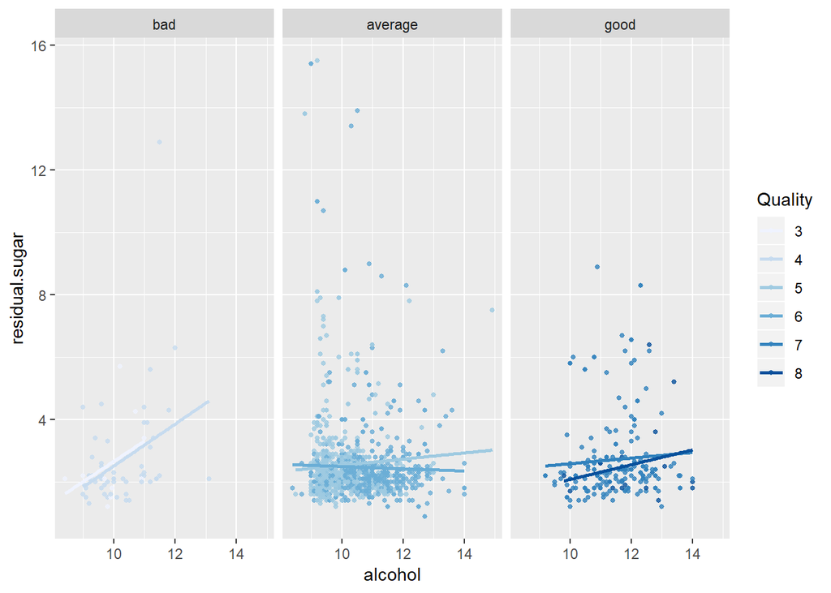

No correlation between residual sugar and quality.

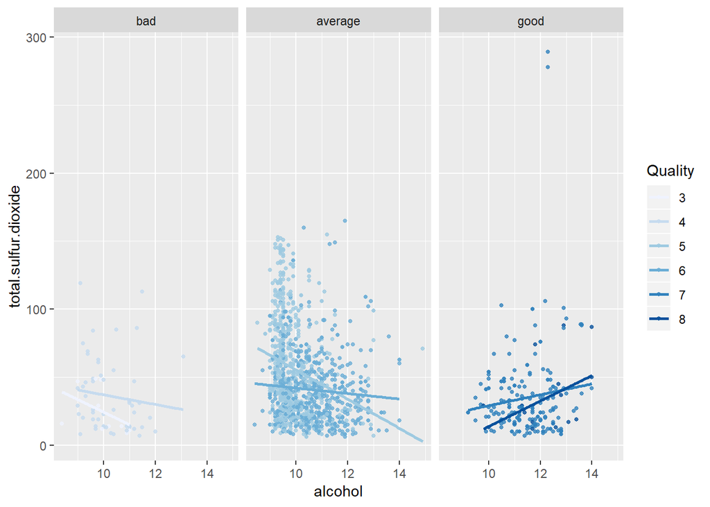

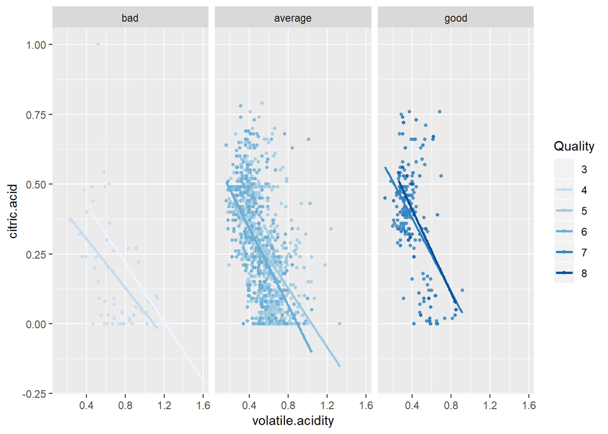

Higher Citric Acid and low Volatile Acid seems to produce better Wines.

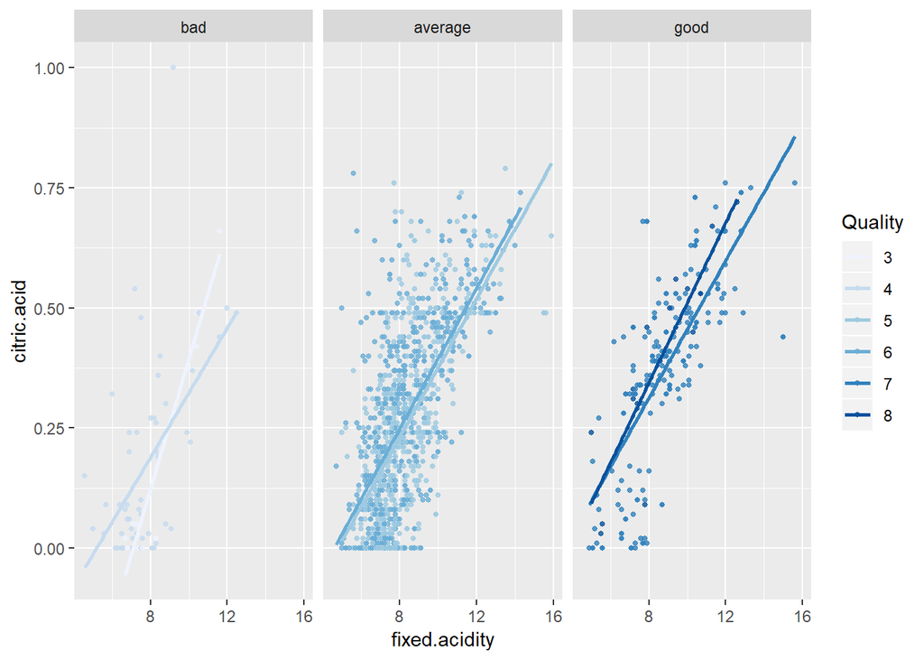

No much correlations

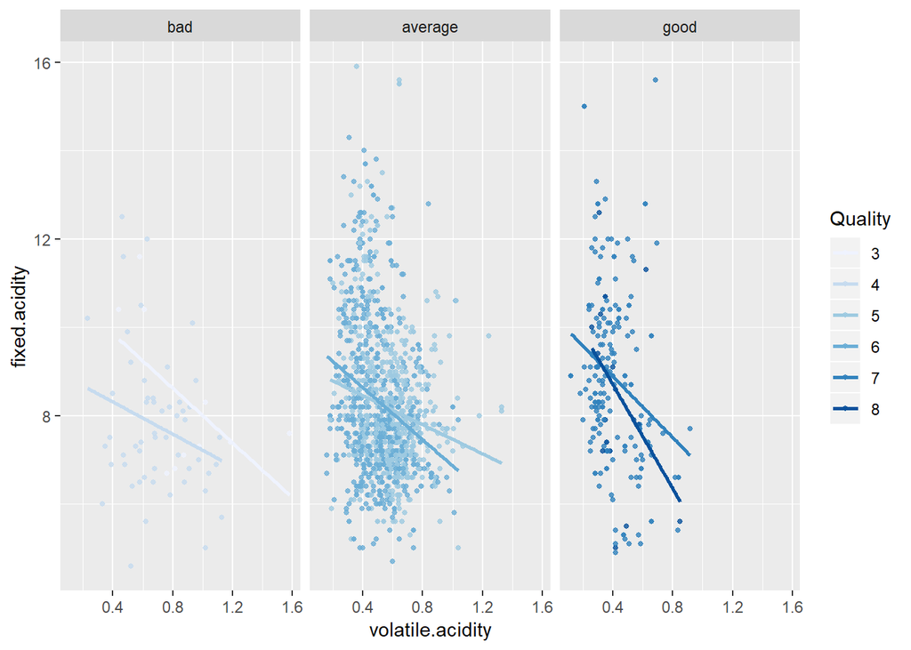

Again, I don’t get much correlation with the quality here.

## Linear Modelling

Now after all these analysis, I am going to take the variables which are most strongly correlated with the quality of the wine and generate a linear model with them.

```
##
## Calls:
## m1: lm(formula = as.numeric(quality) ~ alcohol, data = training_data)
## m2: lm(formula = as.numeric(quality) ~ alcohol + sulphates, data = training_data)
## m3: lm(formula = as.numeric(quality) ~ alcohol + sulphates + volatile.acidity,
##     data = training_data)
## m4: lm(formula = as.numeric(quality) ~ alcohol + sulphates + volatile.acidity +
##     citric.acid, data = training_data)
## m5: lm(formula = as.numeric(quality) ~ alcohol + sulphates + volatile.acidity +
##     citric.acid + fixed.acidity, data = training_data)
## m6: lm(formula = as.numeric(quality) ~ alcohol + sulphates + pH,
##     data = training_data)
##
## ====================================================================================================
##                          m1            m2           m3           m4           m5           m6
## ----------------------------------------------------------------------------------------------------
##   (Intercept)           0.155        -0.273        0.866***     0.973***     0.497        1.494**
##                        (0.220)       (0.224)      (0.247)      (0.254)      (0.287)      (0.515)
##   alcohol               0.333***      0.320***     0.286***     0.284***     0.296***     0.339***
##                        (0.021)       (0.021)      (0.020)      (0.020)      (0.020)      (0.021)
##   sulphates                           0.855***     0.599***     0.650***     0.667***     0.733***
##                                      (0.126)      (0.124)      (0.127)      (0.126)      (0.129)
##   volatile.acidity                                -1.153***    -1.279***    -1.352***
##                                                   (0.124)      (0.143)      (0.144)
##   citric.acid                                                  -0.231       -0.629***
##                                                                (0.132)      (0.174)
##   fixed.acidity                                                              0.058***
##                                                                             (0.017)
##   pH                                                                                     -0.569***
##                                                                                          (0.149)
## ----------------------------------------------------------------------------------------------------
##   R-squared             0.209         0.245        0.308        0.310        0.319        0.256
##   adj. R-squared        0.208         0.243        0.306        0.307        0.315        0.254
##   sigma                 0.707         0.691        0.662        0.661        0.657        0.686
##   F                   252.335       155.125      141.769      107.317       89.264      109.700
##   p                     0.000         0.000        0.000        0.000        0.000        0.000
##   Log-likelihood    -1027.549     -1004.996     -963.139     -961.610     -955.575     -997.782
##   Deviance            478.652       456.660      418.487      417.154      411.937      449.841
##   AIC                2061.098      2017.992     1936.279     1935.219     1925.150     2005.565
##   BIC                2075.695      2037.456     1960.608     1964.415     1959.211     2029.894
##   N                   959           959          959          959          959          959
## ====================================================================================================
```

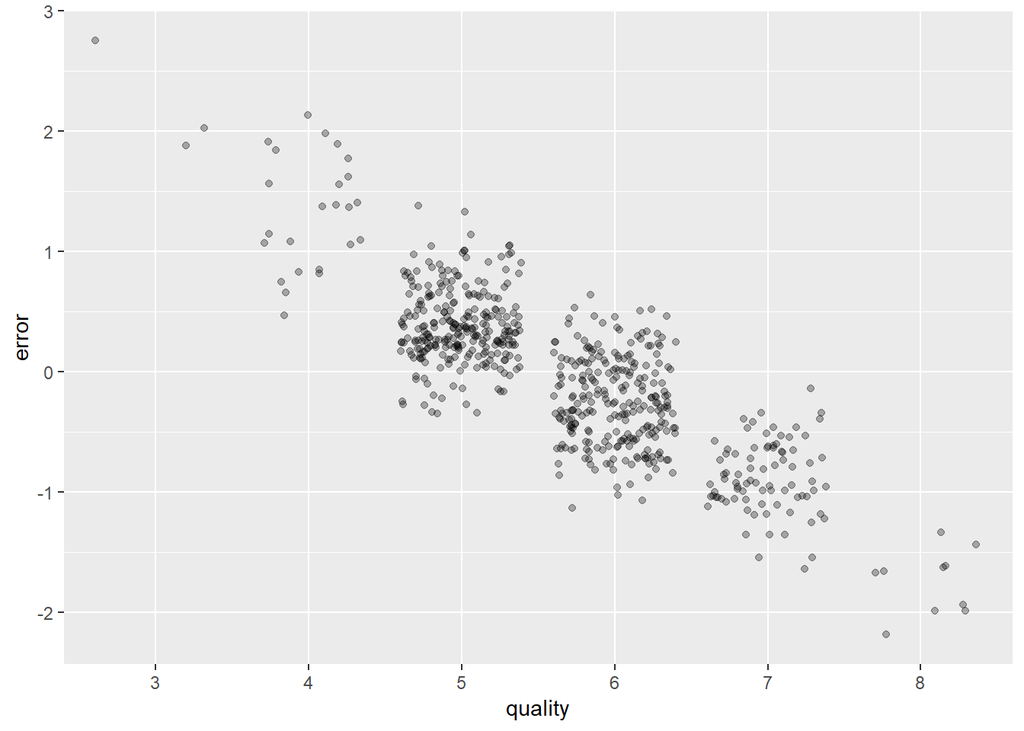

## Analysis of the Multivariate Plots

### Observations

1. High Alcohol and Sulaphate satisfied appears to produce better wines.
2. Citric Acid, level however weakly correlated theatres a part in refining the wine quality.

### Linear Models Created

As we can see that alcohol subsidizes to only 22% of the Wine Quality and furthermost of the factors met on the Average quality wines. This can be since the dataset limited mostly of ‘Average’ quality wines and as there were very few data about the ‘Good’ and the ‘Bad’ quality wines in the dataset, that’s why it was hard to predict statistics for the superiority cases.

## Final Plots and Summary

AS we can see that the Alcohol and Sulphates played a major role in defining alcohol quality.

### Plot 1

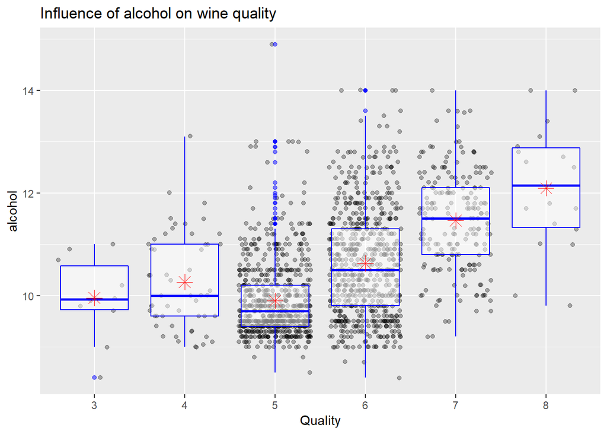

### Plot 2

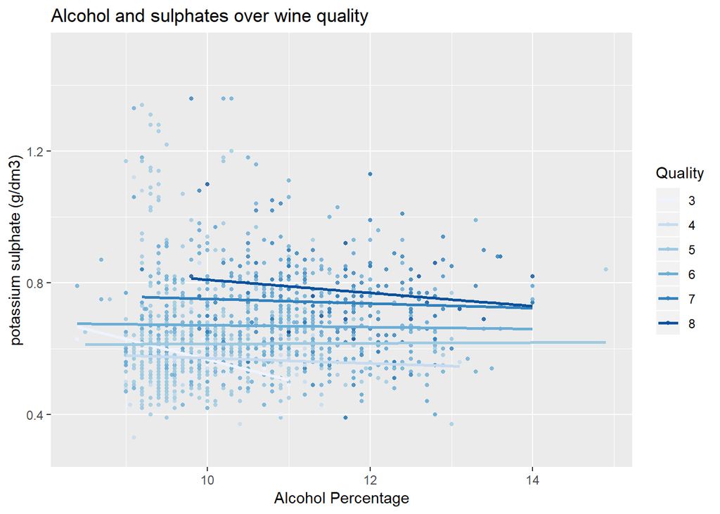

As we can see from the previous plot that Alcohol percentage has played a big role in determining the quality of Wines. The higher the alcohol percentage, the better the wine quality.

### Plot 3

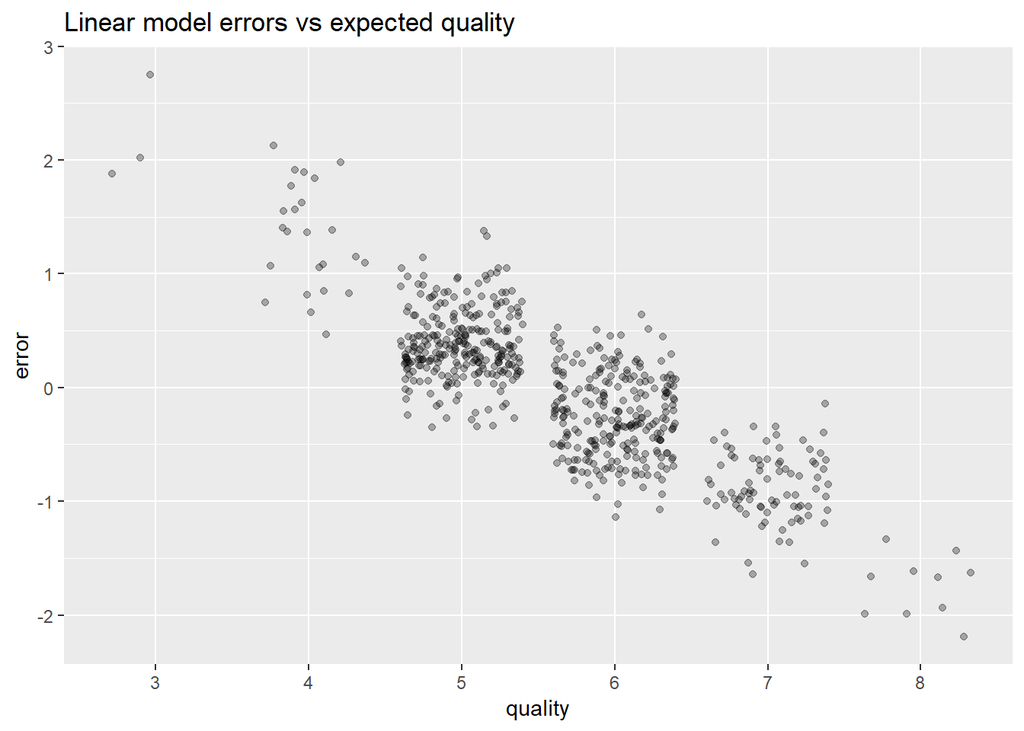

## Reflections

As describe in the begging my goal was to get a higher assurance level when guessing factors that are responsible for the production of diverse quality of wines especially the ‘Good’ and the ‘Bad’ ones.

However I found that some wines didn’t have citric acid at all. Also the others displayed almost a rectangular spreading. My first thought was maybe this was not very clear data or incomplete data. But I do an extra step to researched further about wines. I saw that citric acid essentially is added to some wines to increase the acidity. So that some wines would not have Citric Acid at all. And this matched with my analysis.

Moreover there were more variables showed either a Positively skewed neither Normal Distribution.

Si I have used different plot by using different variables counter to the quality to look into Univariate relationships between them . And after that one by one I chucked in one or more outside factors to see if they composed have any effect on the categorical variable. So the outcome that I have found is some factors which precious the quality of the wine were Alcohol percentage, Sulphate and Acid concentrations. Then I try to figure out the effect of each specific acid on the overall PH of the wine. I found out a very strange wonder where I found that for volatile acids, the pH is cumulative with acidity which was counter to everything. So in final part of the analysis, we used multivariate plots to check if there were some exciting mixtures of variables which together affected the overall quality of the wine we found out that density did not play a part in improving wine quality. For future analysis, I would love to have a dataset, where apart from the wine quality, a rank is given for that particular wine by 5 different wine tasters as we know when we include the human element, our opinion changes on so many different factors. So by including the human element in my analysis, I would be able to put in that perspective and see a lot of unseen factors which might result in a better or worse wine quality. Having these factors included inside the dataset would result in a different insight altogether in my analysis.